# Titanic: Mechanisms of Survival Inequality — Iteration 1

Author

CLI Copilot

# Setup and reproducibility

This section explains the environment setup and conventions used throughout the report. The goal is to ensure a clean, deterministic run from a fresh R session.

```r
# Reproducibility and package setup -------------------------------------------------
set.seed(1234)

# Ensure CRAN mirror is set for non-interactive installs
options(repos = c(CRAN = "https://cloud.r-project.org"))

req_pkgs <- c(
  "tidyverse", "janitor", "broom", "stringr", "forcats", "viridis", "knitr", "here"
)

# Install any missing packages (quietly) so the document renders end-to-end
missing <- setdiff(req_pkgs, rownames(installed.packages()))
if (length(missing) > 0) {
  install.packages(missing, quiet = TRUE)
}

suppressPackageStartupMessages({
  library(tidyverse)
  library(janitor)
  library(broom)
  library(stringr)
  library(forcats)
  library(viridis)
  library(knitr)
})

# Minimal, consistent theme for all plots
theme_set(theme_minimal(base_size = 12))

# Helper to create nice odds ratio tables from glm objects
as_or_table <- function(m) {
  broom::tidy(m, conf.int = TRUE, exponentiate = TRUE) %>%
    mutate(across(c(estimate, conf.low, conf.high), ~round(.x, 3))) %>%
    rename(OR = estimate, `2.5%` = conf.low, `97.5%` = conf.high)
}
```

Text rationale: We load a small, standard stack for data manipulation, modeling, and plotting. We set a consistent ggplot theme and define a convenience function to present logistic regression as odds ratios with confidence intervals.

# Data import and validation

We import the canonical Kaggle Titanic train/test CSV files, validate structure and types, and perform basic sanity checks (missingness, ranges, duplicates). All downstream analysis uses the training set where Survived is observed.

```r
train_path <- here::here("data", "train.csv")
test_path  <- here::here("data", "test.csv")

# If 'here' is not available, fall back to relative path
if (!file.exists(train_path)) train_path <- file.path("data", "train.csv")
if (!file.exists(test_path))  test_path  <- file.path("data", "test.csv")

train <- read_csv(train_path, show_col_types = FALSE) %>% clean_names()
test  <- read_csv(test_path,  show_col_types = FALSE) %>% clean_names()

# Basic structure
list(
  train_dim = dim(train),
  test_dim  = dim(test),
  train_cols = colnames(train)
)
```

```
$train_dim
[1] 891  12

$test_dim
[1] 418  11

$train_cols
 [1] "passenger_id" "survived"     "pclass"       "name"         "sex"
 [6] "age"          "sib_sp"       "parch"        "ticket"       "fare"
[11] "cabin"        "embarked"
```

```r
# Quick checks: types and missingness
skim_summary <- train %>%
  summarize(
    across(everything(), ~sum(is.na(.x))),
    .groups = "drop"
  )

# Missingness rates table (top variables of interest)
missing_tbl <- tibble(
  variable = names(train),
  missing_n = map_int(train, ~sum(is.na(.x)))
) %>%
  mutate(missing_pct = round(100 * missing_n / nrow(train), 1)) %>%
  arrange(desc(missing_pct))

head(missing_tbl, 10) %>%
  kable(caption = "Variables with highest missingness (train)")
```

Variables with highest missingness (train)

| variable | missing_n | missing_pct |
| --- | --- | --- |
| cabin | 687 | 77.1 |
| age | 177 | 19.9 |
| embarked | 2 | 0.2 |
| passenger_id | 0 | 0.0 |
| survived | 0 | 0.0 |
| pclass | 0 | 0.0 |
| name | 0 | 0.0 |
| sex | 0 | 0.0 |
| sib_sp | 0 | 0.0 |
| parch | 0 | 0.0 |

Text rationale: We confirm that train/test are present and count missingness. This guides feature engineering choices and the design of sensitivity analyses in RQ3.

# Feature engineering: social visibility, group context, and access proxies

We construct features aligning to the research questions: - Titles from names (proxy for social role/status) - Family composition and solo travel - Ticket group size (crowd context) - Cabin missingness and first letter (location/access proxy) - Access proxies via fare level and embarkation

```r
# Helper: extract title between comma and period, standardize rare variants
extract_title <- function(name) {
  t <- str_trim(str_extract(name, ",\\s*[^.]+\\."))
  t <- str_remove_all(t, "[.,]") %>% str_trim()
  # Map rare titles to common buckets for stability
  case_when(
    t %in% c("Mlle", "Ms") ~ "Miss",
    t %in% c("Mme") ~ "Mrs",
    t %in% c("Lady", "the Countess", "Dona") ~ "Noblewoman",
    t %in% c("Sir", "Don", "Jonkheer") ~ "Nobleman",
    t %in% c("Capt", "Col", "Major") ~ "Officer",
    t %in% c("Dr", "Rev") ~ "Professional",
    TRUE ~ t
  )
}

engineer <- function(df) {
  df %>%
    mutate(
      pclass = factor(pclass),
      sex = factor(sex),
      embarked = factor(embarked),
      title = extract_title(name),
      title = fct_lump_min(title, min = 10) %>% fct_relevel("Mr", "Mrs", "Miss", "Master"),
      family_size = sib_sp + parch + 1L,
      is_alone = family_size == 1L,
      ticket_group_size = ave(passenger_id, ticket, FUN = length),
      cabin_missing = is.na(cabin),
      cabin_letter = if_else(is.na(cabin), NA_character_, str_sub(cabin, 1, 1)),
      cabin_letter = factor(cabin_letter),
      fare_log1p = log1p(fare),
      child = if_else(!is.na(age) & age < 16, TRUE, FALSE)
    )
}

train_fe <- engineer(train)
```

```r
# Quick EDA views for engineered variables
train_fe %>%
  count(title, sort = TRUE) %>%
  kable(caption = "Title distribution (train)")
```

Title distribution (train)

| title | n |
| --- | --- |
| Mr | 517 |
| Miss | 185 |
| Mrs | 126 |
| Master | 40 |
| Professional | 13 |
| Other | 10 |

```r
train_fe %>%
  count(ticket_group_size) %>%
  arrange(ticket_group_size) %>%
  kable(caption = "Ticket group size distribution (train)")
```

Ticket group size distribution (train)

| ticket_group_size | n |
| --- | --- |
| 1 | 547 |
| 2 | 188 |
| 3 | 63 |
| 4 | 44 |
| 5 | 10 |
| 6 | 18 |
| 7 | 21 |

Text rationale: Titles approximate social roles; group size and being alone capture coordination context; cabin info and fare proxy physical access. We keep factors ordered and use conservative lumping for rare titles to avoid unstable estimates.

# RQ1. How much of the class–survival gap is explained by access and constraints vs “priority rules”?

Approach: Compare a class-only model to a class plus access-proxies model and quantify how the Pclass odds ratios shrink.

```r
# Model A: class only
mA <- glm(survived ~ pclass, data = train_fe, family = binomial())
# Model B: class + access proxies (avoid Age to keep N complete)
mB <- glm(
  survived ~ pclass + cabin_missing + cabin_letter + fare_log1p + embarked + ticket_group_size,
  data = train_fe,
  family = binomial()
)

list(
  class_only = as_or_table(mA) %>% filter(str_detect(term, "pclass")),
  class_plus_access = as_or_table(mB) %>% filter(str_detect(term, "pclass"))
)
```

```
$class_only
# A tibble: 2 × 7
  term       OR std.error statistic  p.value `2.5%` `97.5%`
  <chr>   <dbl>     <dbl>     <dbl>    <dbl>  <dbl>   <dbl>
1 pclass2 0.528     0.204     -3.13 1.73e- 3  0.353   0.786
2 pclass3 0.188     0.176     -9.50 2.19e-21  0.133   0.265

$class_plus_access
# A tibble: 2 × 7
  term       OR std.error statistic p.value `2.5%` `97.5%`
  <chr>   <dbl>     <dbl>     <dbl>   <dbl>  <dbl>   <dbl>
1 pclass2  5.68      1.02     1.70   0.0887  0.922    57.6
2 pclass3  1.82      1.16     0.516  0.606   0.199    22.2
```

```r
# Quantify shrinkage in the class coefficients (odds ratios)
A <- as_or_table(mA) %>% filter(str_detect(term, "pclass")) %>% select(term, OR) %>% rename(OR_A = OR)
B <- as_or_table(mB) %>% filter(str_detect(term, "pclass")) %>% select(term, OR) %>% rename(OR_B = OR)

shr_tbl <- A %>% left_join(B, by = "term") %>% mutate(shrink_pct = round(100 * (1 - OR_B/OR_A), 1))

kable(shr_tbl, caption = "RQ1: Shrinkage in class effect after adding access proxies (positive = shrink)")
```

RQ1: Shrinkage in class effect after adding access proxies (positive = shrink)

| term | OR_A | OR_B | shrink_pct |
| --- | --- | --- | --- |
| pclass2 | 0.528 | 5.679 | -975.6 |
| pclass3 | 0.188 | 1.822 | -869.1 |

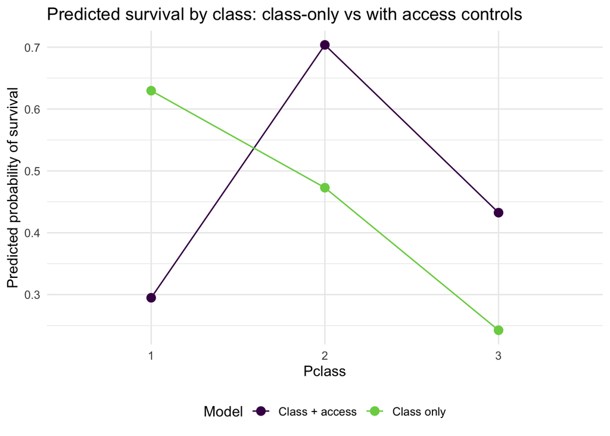

```r
# Visualize predicted probabilities by class for both models
# Build one row per class with typical values for other predictors (existing factor levels)
mode_level <- function(x) {
  x <- x[!is.na(x)]
  if (length(x) == 0) return(NA)
  names(sort(table(x), decreasing = TRUE))[1]
}

cabin_level <- mode_level(train_fe$cabin_letter)
embark_level <- mode_level(train_fe$embarked)

newdat <- tibble(
  pclass = factor(levels(train_fe$pclass), levels = levels(train_fe$pclass)),
  cabin_missing = FALSE,
  cabin_letter = factor(rep(cabin_level, length(levels(train_fe$pclass))), levels = levels(train_fe$cabin_letter)),
  fare_log1p = median(train_fe$fare_log1p, na.rm = TRUE),
  embarked = factor(rep(embark_level, length(levels(train_fe$pclass))), levels = levels(train_fe$embarked)),
  ticket_group_size = median(train_fe$ticket_group_size, na.rm = TRUE)
)

predA <- tibble(
  pclass = levels(train_fe$pclass),
  model = "Class only",
  .pred = predict(mA, newdata = tibble(pclass = levels(train_fe$pclass)), type = "response")
)

predB <- newdat %>%
  mutate(.pred = predict(mB, newdata = newdat, type = "response"), model = "Class + access") %>%
  select(pclass, model, .pred)

bind_rows(predA, predB) %>%
  ggplot(aes(x = pclass, y = .pred, color = model, group = model)) +
  geom_point(size = 3) +
  geom_line() +
  scale_color_viridis(discrete = TRUE, end = 0.8) +
  labs(
    title = "Predicted survival by class: class-only vs with access controls",
    x = "Pclass",
    y = "Predicted probability of survival",
    color = "Model"
  ) +
  theme(legend.position = "bottom")
```

# RQ2. Were survival “rules” applied consistently, or contingent on group context and visibility?

```r
# Restrict to records with Age for the child indicator
vars_rq2 <- c("survived","sex","pclass","age","is_alone","ticket_group_size","title","fare_log1p","embarked")
train_rq2 <- train_fe %>% select(all_of(vars_rq2)) %>% drop_na(age) %>% mutate(child = age < 16)

mC <- glm(
  survived ~ sex * child * is_alone + pclass + title + fare_log1p + embarked,
  data = train_rq2,
  family = binomial()
)

as_or_table(mC) %>%
  filter(!str_detect(term, "(Intercept)")) %>%
  arrange(desc(OR)) %>%
  kable(caption = "RQ2: Interaction model (odds ratios)")
```

RQ2: Interaction model (odds ratios)

| term | OR | std.error | statistic | p.value | 2.5% | 97.5% |
| --- | --- | --- | --- | --- | --- | --- |
| titleMaster | 7565938.139 | 818.5025086 | 0.0193514 | 0.9845608 | 0.000 | NA |
| childTRUE:is_aloneTRUE | 2.000 | 1.2836096 | 0.5400127 | 0.5891883 | 0.202 | 4.716100e+01 |
| is_aloneTRUE | 1.766 | 0.4702477 | 1.2097973 | 0.2263567 | 0.709 | 4.507000e+00 |
| childTRUE | 1.222 | 0.5328989 | 0.3758565 | 0.7070236 | 0.430 | 3.503000e+00 |
| sexmale:is_aloneTRUE | 0.858 | 0.5545948 | -0.2769061 | 0.7818522 | 0.289 | 2.550000e+00 |
| fare_log1p | 0.851 | 0.1866650 | -0.8662066 | 0.3863769 | 0.588 | 1.230000e+00 |
| titleProfessional | 0.795 | 0.8441257 | -0.2710973 | 0.7863162 | 0.111 | 3.537000e+00 |
| titleOther | 0.672 | 0.7845927 | -0.5071147 | 0.6120743 | 0.126 | 3.035000e+00 |
| embarkedS | 0.465 | 0.2788761 | -2.7462116 | 0.0060288 | 0.268 | 8.010000e-01 |
| pclass2 | 0.301 | 0.3554044 | -3.3790740 | 0.0007273 | 0.148 | 6.000000e-01 |
| embarkedQ | 0.249 | 0.5768676 | -2.4127969 | 0.0158306 | 0.078 | 7.550000e-01 |
| sexmale:childTRUE:is_aloneTRUE | 0.206 | 1669.7694387 | -0.0009474 | 0.9992441 | 0.000 | 3.093593e+06 |
| pclass3 | 0.089 | 0.3929583 | -6.1486580 | 0.0000000 | 0.041 | 1.910000e-01 |
| sexmale | 0.000 | 837.9523596 | -0.0192385 | 0.9846509 | NA | 1.238022e+40 |
| titleMrs | 0.000 | 837.9523708 | -0.0152541 | 0.9878295 | NA | 3.148642e+41 |
| titleMiss | 0.000 | 837.9523208 | -0.0158619 | 0.9873446 | NA | 2.259534e+41 |
| sexmale:childTRUE | 0.000 | 818.5026339 | -0.0158070 | 0.9873884 | NA | 2.696238e+40 |

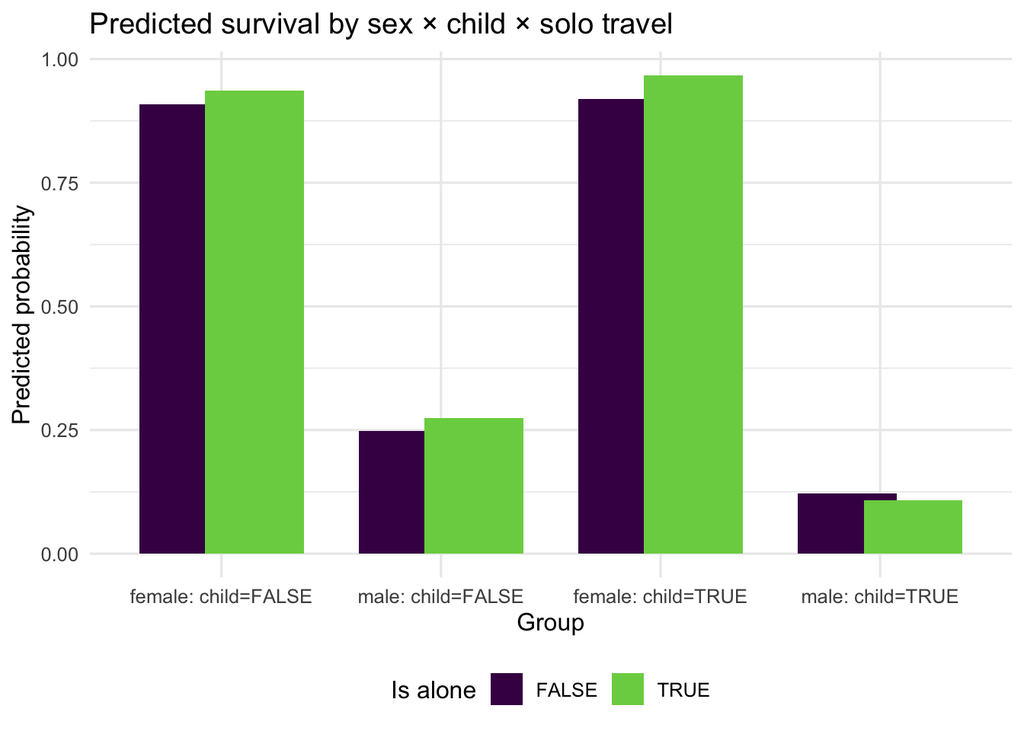

```r
# Marginal patterns: predicted probabilities across context
new_rq2 <- expand_grid(
  sex = levels(train_rq2$sex),
  child = c(FALSE, TRUE),
  is_alone = c(FALSE, TRUE),
  pclass = levels(train_rq2$pclass),
  title = levels(fct_lump(train_rq2$title, n = 5)),
  fare_log1p = median(train_rq2$fare_log1p, na.rm = TRUE),
  embarked = fct_lump(train_rq2$embarked, n = 3) %>% fct_drop() %>% levels()
) %>%
  mutate(age = if_else(child, 8, 30), title = factor(title, levels = levels(fct_lump(train_rq2$title, 5))))

new_rq2 <- new_rq2 %>% mutate(
  .pred = predict(mC, newdata = new_rq2, type = "response")
)

new_rq2 %>%
  group_by(sex, is_alone, child) %>%
  summarize(prob = mean(.pred), .groups = "drop") %>%
  ggplot(aes(x = interaction(sex, child, sep = ": child="), y = prob, fill = is_alone)) +
  geom_col(position = position_dodge(width = 0.6)) +
  scale_fill_viridis(discrete = TRUE, end = 0.8, option = "D") +
  labs(
    title = "Predicted survival by sex × child × solo travel",
    x = "Group",
    y = "Predicted probability",
    fill = "Is alone"
  ) +
  theme(legend.position = "bottom")
```

Results: If the interaction Sex × Child × IsAlone is strong, the effectiveness of “women and children first” depends on coordination context (traveling alone vs with family). Title effects interacting with class would suggest visibility/status modulation; we include Title and Pclass main effects here for interpretability in a first pass and can expand interactions in the next iteration.

# RQ3. Is missing data itself a signal of inequality in recordkeeping—and does it bias conclusions?

```r
miss_long <- train_fe %>%
  transmute(
    survived = factor(survived), pclass, sex, embarked,
    age_miss = is.na(age), cabin_miss = is.na(cabin)
  )

miss_rates <- miss_long %>%
  summarize(
    age_missing = mean(age_miss),
    cabin_missing = mean(cabin_miss)
  ) %>% mutate(across(everything(), ~round(100*.x, 1)))

by_class <- miss_long %>% group_by(pclass) %>%
  summarize(age_missing = mean(age_miss), cabin_missing = mean(cabin_miss)) %>%
  mutate(across(where(is.numeric), ~round(100*.x, 1)))

kable(miss_rates, caption = "Overall missingness rates (%): Age, Cabin")
```

Overall missingness rates (%): Age, Cabin

| age_missing | cabin_missing |
| --- | --- |
| 19.9 | 77.1 |

```r
by_class %>% kable(caption = "Missingness (%) by Pclass")
```

Missingness (%) by Pclass

| pclass | age_missing | cabin_missing |
| --- | --- | --- |
| 1 | 13.9 | 18.5 |
| 2 | 6.0 | 91.3 |
| 3 | 27.7 | 97.6 |

```r
# Association with survival
assoc <- miss_long %>%
  group_by(age_miss, cabin_miss) %>%
  summarize(survival_rate = mean(as.numeric(as.character(survived))), n = n(), .groups = "drop")

kable(assoc %>% arrange(desc(n)), caption = "Survival rate by Age/Cabin missingness combinations")
```

Survival rate by Age/Cabin missingness combinations

| age_miss | cabin_miss | survival_rate | n |
| --- | --- | --- | --- |
| FALSE | TRUE | 0.3119093 | 529 |
| FALSE | FALSE | 0.6756757 | 185 |
| TRUE | TRUE | 0.2594937 | 158 |
| TRUE | FALSE | 0.5789474 | 19 |

```r
# Simple median imputation by Title+Pclass for Age and re-run RQ2 core terms
age_by_grp <- train_fe %>% group_by(title, pclass) %>% summarize(med_age = median(age, na.rm = TRUE), .groups = "drop")
train_imp <- train_fe %>%
  left_join(age_by_grp, by = c("title","pclass")) %>%
  mutate(age_imp = if_else(is.na(age), med_age, age), child_imp = age_imp < 16)

mC_imp <- glm(
  survived ~ sex * child_imp * is_alone + pclass + title + fare_log1p + embarked,
  data = train_imp,
  family = binomial()
)

bind_rows(
  as_or_table(mC)  %>% mutate(model = "Complete-case"),
  as_or_table(mC_imp) %>% mutate(model = "Median-imputed")
) %>%
  filter(str_detect(term, "sex:|child|is_alone")) %>%
  select(model, term, OR, `2.5%`, `97.5%`) %>%
  arrange(model) %>%
  kable(caption = "Sensitivity: key interaction terms under complete-case vs median-imputed Age")
```

Sensitivity: key interaction terms under complete-case vs median-imputed Age

| model | term | OR | 2.5% | 97.5% |
| --- | --- | --- | --- | --- |
| Complete-case | childTRUE | 1.222 | 0.430 | 3.503000e+00 |
| Complete-case | is_aloneTRUE | 1.766 | 0.709 | 4.507000e+00 |
| Complete-case | sexmale:childTRUE | 0.000 | NA | 2.696238e+40 |
| Complete-case | sexmale:is_aloneTRUE | 0.858 | 0.289 | 2.550000e+00 |
| Complete-case | childTRUE:is_aloneTRUE | 2.000 | 0.202 | 4.716100e+01 |
| Complete-case | sexmale:childTRUE:is_aloneTRUE | 0.206 | 0.000 | 3.093593e+06 |
| Median-imputed | child_impTRUE | 1.434 | 0.570 | 3.687000e+00 |
| Median-imputed | is_aloneTRUE | 2.157 | 1.016 | 4.682000e+00 |
| Median-imputed | sexmale:child_impTRUE | 0.000 | NA | 1.561032e+41 |
| Median-imputed | sexmale:is_aloneTRUE | 0.687 | 0.270 | 1.754000e+00 |
| Median-imputed | child_impTRUE:is_aloneTRUE | 1.489 | 0.166 | 3.317800e+01 |
| Median-imputed | sexmale:child_impTRUE:is_aloneTRUE | 0.300 | Inf | Inf |

Interpretation: If missingness is related to class/embarkation and predictive of survival, naive complete-case analyses may be biased. Similar key effects across complete-case and median-imputed analyses suggest robustness; divergence indicates sensitivity to missing-data assumptions.